# Домашняя работа по определению характеристик индивида, влияющих на наличие у него смртфона

Иван Мишалкин

11 2017

В этой работе мы постараемсявыяснить, какие характеристики индивида влияют на наличие у него смартфона. Мы будем использовать данные РМЭЗ.

### Подготовка данных и предварительный анализ

Нас будет интересовать только работающее население, поэтому отфильтруем нашу исходную выборку.

Создадим целевую переменную smartphone, на основе вопроса “У Вас лично есть смартфон, коммуникатор, i-phone (ай-фон)?”.

Далее необходимо выделить характеристики, которые могут быть влиять на нашу целевую переменную. Так как признаков 72, для начала мы обучим алгоритм случайного леса, которые покажет нам переменные, разбиения по которым дают наибольшую информацию, так называемые “feature importances”. Далее, мы посмотрим, какие еще переменные можно включить в анализ.

[figure not shown]

Для построения этого графика были убраны значения с большим количеством пропусков. Как правило, это характерно для уточняющих вопросов. Так, например, после вопроса о браке идет вопрос о дате регистрации брака. Так случайный лес мы строили по 52 наблюдениям из 72.

Самым информативным признаком оказался tj184, который является ответом на вопрос есть ли у вас мобильный телефон. Причем, корреляция между наличием мобильного телефон и наличием смартфона отрицательная -0.6713773. Это говорит о том, что в нашей выборке количество людей с обычными телефонами больше, чем со смартфонами, так как смартфон является телефоном, но не наоборот. Первая таблица показывает количество людей со смартфоном(1) и без(0)

| 0 | 1 |
| --- | --- |
| 2134 | 743 |

На второй таблице количество людей с мобильным телефоном

| Да | Нет |
| --- | --- |
| 2299 | 578 |

В дальнейшем tj184 будет переименована в simplephone. Делее по значимости идет вопрос “Вы пользуетесь для выхода в Интернет мобильным телефоном или смартфоном?” под кодом tj359_3. Переименуем в webphone. Далее идут региональные переменные. tj4_1 отвечает за отрасль, переименум ее в industry. tj401_2a - “Вы посещаете социальную сеть Вконтакте?”, переименуем в vk. Сделаем то же самое для Одноклассников, назовем переменную ok. t_educ - образование. th6, tj69_9c - год рождения респондента, мы будем пользоваться t_age. popul - численность населения в месте проживания респондента. t_occup08 служащая группа, у нас уже естьотрасль. Также мы включим доход и пол респондентов.

Посмотрим далее на выбросы. Они скорее всего будут в зарплатах.

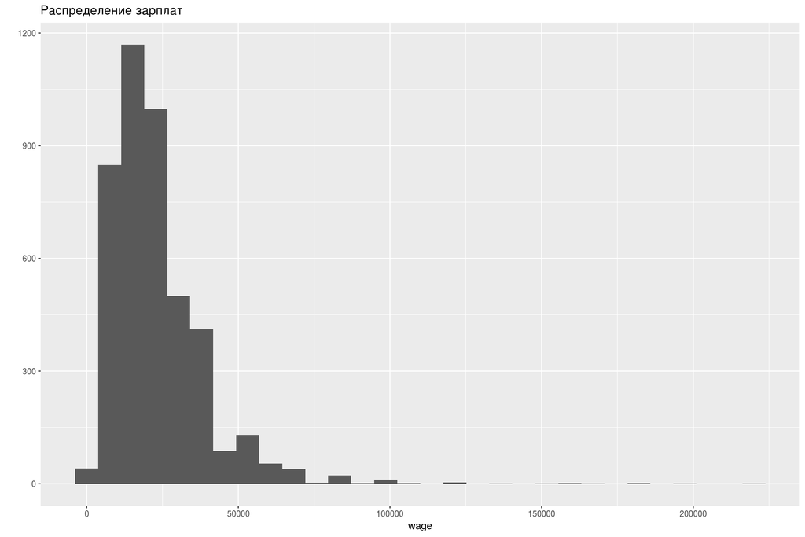

Возьмем 99 перцентиль в качестве максимально восможной зарплаты. А также возьмем логарифм от зарплаты, для приближения распределения к нормальному

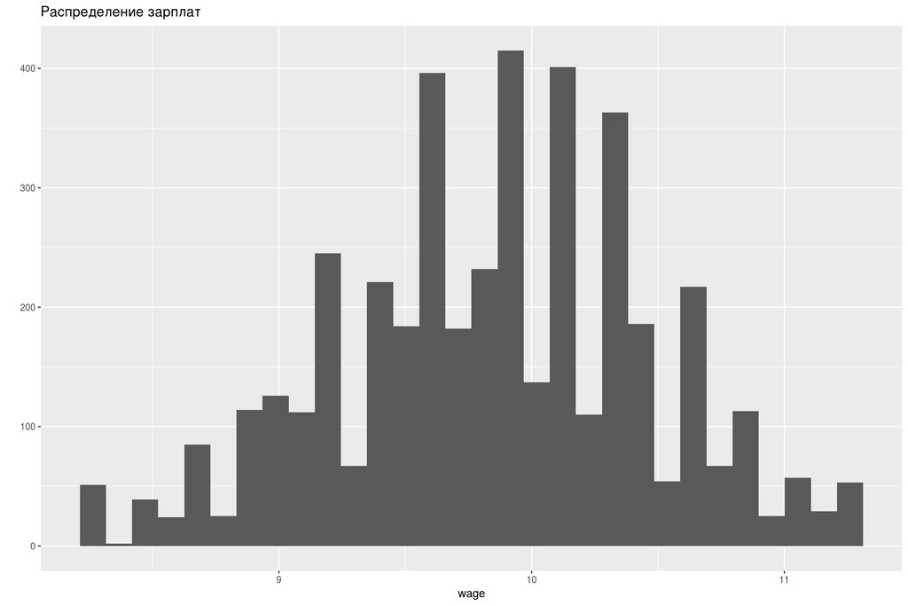

Заврешая первую часть, мы посмотрим на описательную статистику нашей выборки.

Table continues below

| sex | wage | ok | vk | industry |
| --- | --- | --- | --- | --- |
| ЖЕНСКИЙ:2317 | Min. : 8.294 | Да :1696 | Да :1499 | ТОРГОВЛЯ, БЫТОВОЕ ОБСЛУЖИВАНИЕ: 797 |
| МУЖСКОЙ:2015 | 1st Qu.: 9.393 | Нет:2636 | Нет:2833 | ОБРАЗОВАНИЕ : 496 |
|  | Median : 9.903 |  |  | ТРАНСПОРТ, СВЯЗЬ : 388 |
|  | Mean : 9.844 |  |  | ЗДРАВООХРАНЕНИЕ : 366 |
|  | 3rd Qu.:10.309 |  |  | СТРОИТЕЛЬСТВО : 319 |
|  | Max. :11.290 |  |  | ЛЕГКАЯ, ПИЩЕВАЯ ПРОМЫШЛЕННОСТЬ: 269 |
|  |  |  |  | (Other) :1697 |

| webphone | simplephone | t_age | popul | smartphone |
| --- | --- | --- | --- | --- |
| Да :1657 | Да :3370 | Min. :16.00 | Min. : 7 | 0:3050 |
| Нет:2675 | Нет: 962 | 1st Qu.:31.00 | 1st Qu.: 17381 | 1:1282 |
|  |  | Median :41.00 | Median : 111843 |  |
|  |  | Mean :42.11 | Mean : 1354309 |  |
|  |  | 3rd Qu.:52.00 | 3rd Qu.: 744995 |  |
|  |  | Max. :83.00 | Max. :12325387 |  |

### Проверка предложенных гипотез

Сначала необходимо построить линейную вероятностную модель

```
Call:
lm(formula = as.numeric(smartphone) ~ wage + sex + t_age, data = fn)

Residuals:
    Min      1Q  Median      3Q     Max
-0.7492 -0.3216 -0.1387  0.4315  1.1852

Coefficients:
              Estimate Std. Error t value    Pr(>|t|)
(Intercept) -0.3973685  0.1099155  -3.615    0.000304 ***
wage         0.2193071  0.0106788  20.537     < 2e-16 ***
sexМУЖСКОЙ  -0.0689765  0.0129484  -5.327 0.000000105 ***
t_age       -0.0102935  0.0005061 -20.340     < 2e-16 ***
---
Signif. codes:  0 '***' 0.001 '**' 0.01 '*' 0.05 '.' 0.1 ' ' 1

Residual standard error: 0.4109 on 4328 degrees of freedom
Multiple R-squared:  0.1906,    Adjusted R-squared:   0.19
F-statistic: 339.6 on 3 and 4328 DF,  p-value: < 2.2e-16
```

Мы видим, что все регрессоры значимы. С увеличением зарплаты индивид скорее купит смартфон. С возрастом, наоборот, вероятнее человек не будет иметь телефона. Также мужчины менее вероятно обладают смартфоном, чем женщины.

Далее оценим логит модель на те же регрессоры.Логистическая регрессия отличается тем, что предсказанные значения целевой переменной не могут быть больше нуля или меньше единицы. Все выдаваемые значения линейной комбинации параметров преобразуются логистической функцией.

```
Call:
glm(formula = smartphone ~ wage + sex + t_age, family = binomial(link = "logit"),
    data = fn)

Deviance Residuals:
    Min       1Q   Median       3Q      Max
-1.9896  -0.7887  -0.4549   0.9234   2.9627

Coefficients:
              Estimate Std. Error z value Pr(>|z|)
(Intercept) -12.339362   0.730062 -16.902  < 2e-16 ***
wage          1.447720   0.074252  19.498  < 2e-16 ***
sexМУЖСКОЙ   -0.494154   0.079211  -6.238 4.42e-10 ***
t_age        -0.067952   0.003489 -19.475  < 2e-16 ***
---
Signif. codes:  0 '***' 0.001 '**' 0.01 '*' 0.05 '.' 0.1 ' ' 1

(Dispersion parameter for binomial family taken to be 1)

    Null deviance: 5262.4  on 4331  degrees of freedom
Residual deviance: 4287.3  on 4328  degrees of freedom
AIC: 4295.3

Number of Fisher Scoring iterations: 5
```

Все переменные в логит модели с предположением о логистическом распределении случайной ошибки значимы и имеют тот же знак, что и в линейной вероятностной модели. Для оценки качества логистической регрессии нет возможности использовать обычный $R^2$, но можно использовать $R^2$ Мак Фаддена, который в нашем случае равен 0.18, что говорит о не самой лучшей предсказательной силе модели.

```
          llh       llhNull            G2      McFadden          r2ML
-2143.6322680 -2631.1810208   975.0975058     0.1852965     0.2015570
         r2CU
    0.2866201
```

Также можно с помощью теста отношения правдоподобия посмотреть, не равны ли все коэффициенты перед регрессорами нулю.

```
Likelihood ratio test

Model 1: smartphone ~ wage + sex + t_age
Model 2: smartphone ~ 1
  #Df  LogLik Df Chisq Pr(>Chisq)
1   4 -2143.6
2   1 -2631.2 -3 975.1  < 2.2e-16 ***
---
Signif. codes:  0 '***' 0.001 '**' 0.01 '*' 0.05 '.' 0.1 ' ' 1
```

Как видим, p-value низок, а значит коэффициенты при регрессорах не равны нулю.

Для сравнения можно взять наивную модель, которая для всех значений будет возвращать моду целевой переменной. В нашем случае мода это 0. Построим таблицу смежностей для наивной модели

```
Confusion Matrix and Statistics

          Reference
Prediction    0    1
         0 3050 1282
         1    0    0

               Accuracy : 0.7041
                 95% CI : (0.6902, 0.7176)
    No Information Rate : 0.7041
    P-Value [Acc > NIR] : 0.5075

                  Kappa : 0
 Mcnemar's Test P-Value : <2e-16

            Sensitivity : 1.0000
            Specificity : 0.0000
         Pos Pred Value : 0.7041
         Neg Pred Value :    NaN
             Prevalence : 0.7041
         Detection Rate : 0.7041
   Detection Prevalence : 1.0000
      Balanced Accuracy : 0.5000

       'Positive' Class : 0
```

Такая же таблица для логит модели

```
Confusion Matrix and Statistics

          Reference
Prediction    0    1
         0 2730  734
         1  320  548

               Accuracy : 0.7567
                 95% CI : (0.7436, 0.7694)
    No Information Rate : 0.7041
    P-Value [Acc > NIR] : 6.048e-15

                  Kappa : 0.3558
 Mcnemar's Test P-Value : < 2.2e-16

            Sensitivity : 0.8951
            Specificity : 0.4275
         Pos Pred Value : 0.7881
         Neg Pred Value : 0.6313
             Prevalence : 0.7041
         Detection Rate : 0.6302
   Detection Prevalence : 0.7996
      Balanced Accuracy : 0.6613

       'Positive' Class : 0
```

Видно, что наша модель выигрывает как по точности, так и по уровню специфичности.

Далее построим ROC кривую.

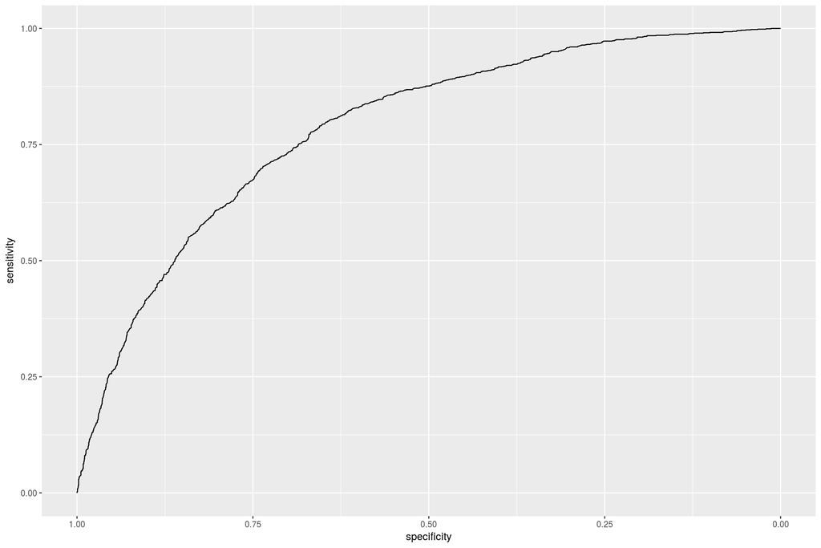

Площадь под ROC кривой 0.7870757, что говорит о среднем качестве модели. То есть наша модель значительно лучше наивной модели, но до единицы еще далековато.

Далее построим логистическую регрессию с большим количеством регрессоров.

```
Call:
glm(formula = smartphone ~ wage + sex + t_age + vk + webphone +
    simplephone + popul, family = binomial(link = "logit"), data = fn)

Deviance Residuals:
    Min       1Q   Median       3Q      Max
-3.4096  -0.2676  -0.1677   0.1502   3.2142

Coefficients:
                     Estimate     Std. Error z value Pr(>|z|)
(Intercept)    -7.42061607656  1.06632565948  -6.959 3.43e-12 ***
wage            0.76573064952  0.10773061138   7.108 1.18e-12 ***
sexМУЖСКОЙ     -0.25233362626  0.11970022305  -2.108   0.0350 *
t_age          -0.01383478136  0.00569592477  -2.429   0.0151 *
vkНет          -0.71942848326  0.12744220188  -5.645 1.65e-08 ***
webphoneНет    -2.68413575985  0.14621830332 -18.357  < 2e-16 ***
simplephoneНет  4.30752154493  0.16148172228  26.675  < 2e-16 ***
popul           0.00000010421  0.00000001788   5.829 5.58e-09 ***
---
Signif. codes:  0 '***' 0.001 '**' 0.01 '*' 0.05 '.' 0.1 ' ' 1

(Dispersion parameter for binomial family taken to be 1)

    Null deviance: 5262.4  on 4331  degrees of freedom
Residual deviance: 2079.3  on 4324  degrees of freedom
AIC: 2095.3

Number of Fisher Scoring iterations: 6
```

Отрасль и времяпрепровождение в социальной сети Одноклассники оказались незначимыми регрессорами и были выброшены из рассмотрения. $R^2$ Мак Фаддена теперь равен 0.6048644. Мы можем провести тест отношений правдоподобий, чтобы посмотреть, не являются ли добавленные регрессоры избыточными.

```
Likelihood ratio test

Model 1: smartphone ~ wage + sex + t_age + vk + webphone + simplephone +
    popul
Model 2: smartphone ~ wage + sex + t_age
  #Df  LogLik Df  Chisq Pr(>Chisq)
1   8 -1039.7
2   4 -2143.6 -4 2207.9  < 2.2e-16 ***
---
Signif. codes:  0 '***' 0.001 '**' 0.01 '*' 0.05 '.' 0.1 ' ' 1
```

p-value мало, значит коэффициенты при новых регрессорах отличны от нуля статистически значимо.

Далее ответим на вопрос, стоит ли отценивать общую модель для мужчин и женщин. Можно провести еще один LR-тест, чтобы выяснить это, но мы просто посмотрим на то, что коэффициент перед полом значим, а значит его исключение крайне маловероятно улучшит модель. Так что лучше оставить эту переменную.

Также нас просят проверить гипотезу о нелинейном влиянии возраста. Возьмем в качестве дополнительного регрессора квадрат возраста.

```
Call:
glm(formula = smartphone ~ wage + sex + t_age + I(t_age^2) +
    vk + webphone + simplephone + popul, family = binomial(link = "logit"),
    data = fn)

Deviance Residuals:
    Min       1Q   Median       3Q      Max
-3.4056  -0.2697  -0.1681   0.1507   3.2424

Coefficients:
                     Estimate     Std. Error z value Pr(>|z|)
(Intercept)    -7.81969779751  1.13284522149  -6.903 5.10e-12 ***
wage            0.74011451467  0.11030423119   6.710 1.95e-11 ***
sexМУЖСКОЙ     -0.23778729417  0.12047742192  -1.974   0.0484 *
t_age           0.02061404352  0.03255309398   0.633   0.5266
I(t_age^2)     -0.00041284944  0.00038490013  -1.073   0.2834
vkНет          -0.73785603942  0.12844894094  -5.744 9.23e-09 ***
webphoneНет    -2.68891954912  0.14609724561 -18.405  < 2e-16 ***
simplephoneНет  4.31434635445  0.16203866581  26.625  < 2e-16 ***
popul           0.00000010561  0.00000001794   5.887 3.94e-09 ***
---
Signif. codes:  0 '***' 0.001 '**' 0.01 '*' 0.05 '.' 0.1 ' ' 1

(Dispersion parameter for binomial family taken to be 1)

    Null deviance: 5262.4  on 4331  degrees of freedom
Residual deviance: 2078.2  on 4323  degrees of freedom
AIC: 2096.2

Number of Fisher Scoring iterations: 6
```

Видно, что коэффициент при возрасте и при квадрате возраста незначимы. Об избыточности квадратичного члена говорит также p-value LR-теста 0.2794552

Итак, в конечном счете исходя из нашей модели можно заключить, что уменьшают вероятность обладания смартфоном следующие факторы: мужской пол, каждый дополнительный год в возрасте, неиспользование социальной сети ВКонтакте, неиспользование мобильного телефона для выхода в интернет. В то же время высокая зарплата и высокое население населенного пункта, в котором проживает человек увеличивает вероятность обладания смартфоном. Также есть спорный регрессор, который говорит, что если у вас нет телефона, то вы вероятнее обладатель смартфона, который, по сути, также является телефоном. Дело в том, что в данной выборке, если у человека есть телефон, то он вероятнее не смартфон. Обратная логика такова, что если телефона нет, то это смартфон. Здесь нарушена причинно-следственная связь. По хорошему стоило оценивать наличие телефона вообще, а наличие смартфона взять регрессором. Далее мы откажемся от этого регрессора из-за его противоречивости и неинтерпретируемости.

Теперь посчитаем вероятность обладать смартфоном индивида с моими характеристиками.

Она будет равна 0.6075549.

Посчитаем предельные эффекты, сначала для индивида с моими характеристиками, далее средний предельный эффект и предельный эффект для среднего представителя.

```
  dydx_wage   dydx_t_age       dydx_popul dydx_sexМУЖСКОЙ dydx_vkНет
1 0.1975103 -0.004476254 0.00000002586359     -0.05869557 -0.1229771
  dydx_webphoneНет
1       -0.4946932
```

```
Call:
logitmfx(formula = logit4, data = fn, atmean = FALSE)

Marginal Effects:
                  dF/dx   Std. Err.        z     P>|z|
wage         1.0040e-01  1.1344e-02   8.8506 < 2.2e-16 ***
sexМУЖСКОЙ  -3.0671e-02  1.1133e-02  -2.7549  0.005871 **
t_age       -2.2754e-03  5.5115e-04  -4.1284 3.652e-05 ***
vkНет       -6.3691e-02  1.2905e-02  -4.9353 8.003e-07 ***
webphoneНет -4.1591e-01  1.7251e-02 -24.1092 < 2.2e-16 ***
popul        1.3147e-08  1.7364e-09   7.5713 3.695e-14 ***
---
Signif. codes:  0 '***' 0.001 '**' 0.01 '*' 0.05 '.' 0.1 ' ' 1

dF/dx is for discrete change for the following variables:

[1] "sexМУЖСКОЙ"  "vkНет"       "webphoneНет"
```

```
Call:
logitmfx(formula = logit4, data = fn, atmean = TRUE)

Marginal Effects:
                  dF/dx   Std. Err.        z     P>|z|
wage         1.3183e-01  1.3522e-02   9.7491 < 2.2e-16 ***
sexМУЖСКОЙ  -4.0247e-02  1.4592e-02  -2.7581  0.005813 **
t_age       -2.9876e-03  7.0630e-04  -4.2299 2.338e-05 ***
vkНет       -8.3051e-02  1.6886e-02  -4.9185 8.723e-07 ***
webphoneНет -4.4990e-01  1.7408e-02 -25.8450 < 2.2e-16 ***
popul        1.7262e-08  2.2077e-09   7.8192 5.318e-15 ***
---
Signif. codes:  0 '***' 0.001 '**' 0.01 '*' 0.05 '.' 0.1 ' ' 1

dF/dx is for discrete change for the following variables:

[1] "sexМУЖСКОЙ"  "vkНет"       "webphoneНет"
```

Можно видеть, так как мои характеристики не похожи на средние, то и предельные эффекты отличаются довольно значительно.

Нас просят изобразить зависимость иметь сматрфон от дохода для мужчин и женщин

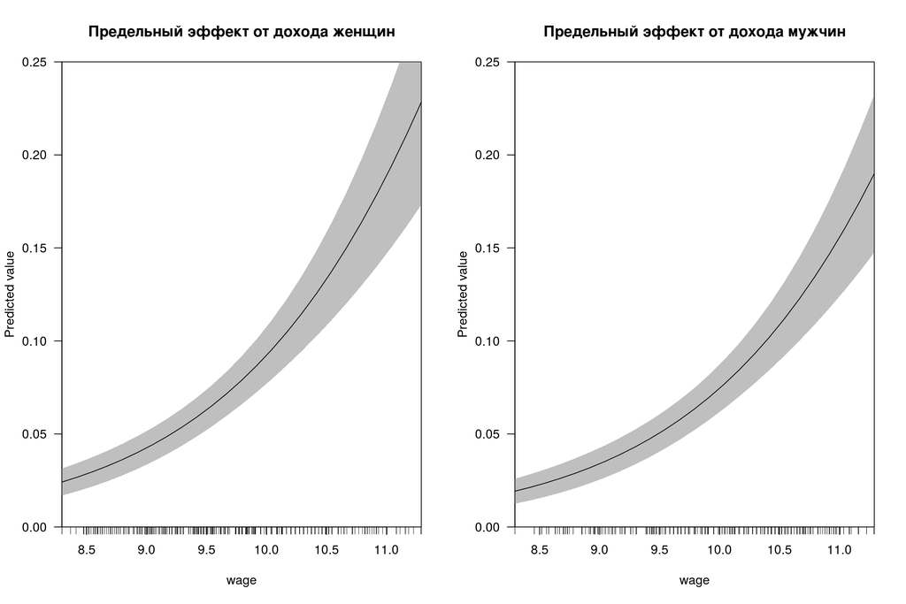

Из недостатков нашей модели можно привести тот факт, что нам пришлось избавиться от значимого регрессора в виду его неинтерпретируемости. Если бы нам удалось собрать данные предоставляющие хотя бы косвенную информацию о наличии обыкновенного мобильного телефона, это могло улучшить нашу модель. Например, вопрос “предпочитаете ли вы кнопочные телефоны” был бы хорошим фактором, определяющим вероятность наличия смартфона.

```r
library(foreign)
library(pander)
library(ggplot2)
library('dplyr')
library(stargazer)
library(ggplot2)
Mode <- function(x) {
  ux <- unique(x)
  ux[which.max(tabulate(match(x, ux)))]
}
options(scipen=4)

df <- read.csv('~/mobile/HW1_binary.csv', na.strings = c("NA", "ЗАТРУДНЯЮСЬ ОТВЕТИТЬ", "ОТКАЗ ОТ ОТВЕТА", "НЕТ ОТВЕТА", "ПРЕМИЮ НЕ ПОЛУЧАЛИ", "ПОЛЬЗУЮТСЯ НЕСКОЛЬКО ЧЛЕНОВ СЕМЬИ"))
df <- df %>% filter(tj1 == 'Вы сейчас работаете')
df <- df %>% filter(tj360_2 %in% c('Да', 'Нет')) %>% mutate(smartphone = ifelse(tj360_2 == 'Да', 1, 0)) %>% select(-tj360_2)


#sapply(df, function(x) sum(is.na(x))) #Проверить в каких колонках NA
library(caret)
rf_df <- subset(df, select = -c(idind, tredid_i,tid_i, tid_h, sid_i, sid_h, t_born_m, tj401_1b,
                                   tj401_2b, tj401_3b, tj401_4b, tj401_5b, tj10_2, tj323y,
                                 tj325y, tj323m, tj325m, tj125_9, th3, t_int_y))
#tj10_2 премия
#tj13_2 вопрос про ваше предприятие
#tj323y год регистрации брака
#tj325y год начала совместного проживания tj325m
#tj125 интернет для чего-то еще дурацкий вопрос
#th3 family number
#t_inwgt weight of the individ
#t_int_y год опроса
set.seed(4543)
fd <- rf_df
rf_df <- na.omit(rf_df)
rf_df$smartphone = as.factor(rf_df$smartphone)
library(randomForest)
rf_out <- randomForest(smartphone ~ ., data=rf_df, ntree=100)

# Extracts variable importance (Mean Decrease in Gini Index)
# Sorts by variable importance and relevels factors to match ordering
var_importance <- data_frame(variable=setdiff(colnames(rf_df), "smartphone"),
                             importance=as.vector(importance(rf_out)))
var_importance <- arrange(var_importance, desc(importance))
var_importance$variable <- factor(var_importance$variable, levels=var_importance$variable)

p <- ggplot(var_importance, aes(x=variable, weight=importance, fill=variable))
p <- p + geom_bar() + ggtitle("Variable Importance from Random Forest Fit")
p <- p + xlab("Demographic Attribute") + ylab("Variable Importance (Mean Decrease in Gini Index)")
p <- p + scale_fill_discrete(name="Variable Name")
p + theme(axis.text.x=element_blank(),
          axis.text.y=element_text(size=12),
          axis.title=element_text(size=16),
          plot.title=element_text(size=18),
          legend.title=element_text(size=16),
legend.text=element_text(size=12))
pander::pandoc.table(table(rf_df$smartphone))
pander::pandoc.table(table(rf_df$tj184))
colnames(fd)[which(colnames(fd) == 'tj184')] <- 'simplephone'
colnames(fd)[which(colnames(fd) == 'tj359_3')] <- 'webphone'
colnames(fd)[which(colnames(fd) == 'tj4_1')] <- 'industry'
colnames(fd)[which(colnames(fd) == 'tj401_2a')] <- 'vk'
colnames(fd)[which(colnames(fd) == 'tj401_1a')] <- 'ok'
colnames(fd)[which(colnames(fd) == 'tj13_2')] <- 'wage'
colnames(fd)[which(colnames(fd) == 'th5')] <- 'sex'
#t_age
#popul
fd$ok[fd$ok == ''] <- 'Нет'
fd$vk[fd$vk == ''] <- 'Нет'
fd$webphone[fd$webphone == ''] <- 'Нет'
fn <- fd %>% select(sex, wage, ok, vk, industry, webphone, simplephone, t_age, popul, smartphone)
fn = droplevels(fn)
na.omit(fn) %>% ggplot() + geom_histogram(aes(wage))+ylab('')+ggtitle('Распределение зарплат')
winsor <- function(df, column, delete.outliers=FALSE){
  df=df[which(!is.na(df[,column])),]
  quantiles <- quantile( df[,column], c(.01, .99 ) )
  if(delete.outliers){
    df[ df[,column] < quantiles[1],column ] <- NA
    df[ df[,column] > quantiles[2],column ] <- NA
    df=df[which(!is.na(df[,column])),]
  } else {
    df[ df[,column] < quantiles[1],column ] <- quantiles[1]
    df[ df[,column] > quantiles[2],column ] <- quantiles[2]
  }
  df
}

fn$wage = log(fn$wage)
fn=na.omit(fn)
fn=winsor(fn,'wage')
fn %>% ggplot() + geom_histogram(aes(wage))+ylab('')+ggtitle('Распределение зарплат')
fn$smartphone <- as.factor(fn$smartphone)
pander::pandoc.table(summary(fn), missing = '')
lmapp <-lm(as.numeric(smartphone) ~ wage + sex +t_age , data=fn)
summary(lmapp)
library(stats)
logit <- glm(smartphone ~ wage + sex +t_age,family=binomial(link='logit'),data=fn)
summary(logit)
library(pscl)
pR2(logit)
library(lmtest)
lrtest(logit)
pred <- predict(logit,newdata=fn[,1:(dim(fn)[2]-1)])
probs <- exp(pred)/(1+exp(pred))
pred_classes = ifelse(probs>=0.5, 1, 0)
confusionMatrix(rep(Mode(fn$smartphone), times=length(fn$smartphone)), fn$smartphone, mode='sens_spec')
confusionMatrix(pred_classes,fn$smartphone, mode='sens_spec')
library(pROC)
rocobj <- roc(fn$smartphone, probs)
library(ggplot2)
ggroc(rocobj)
sum(fn$vk=='')
logit2 <- glm(smartphone ~ wage + sex +t_age + vk + webphone + simplephone + popul,family=binomial(link='logit'),data=fn)
summary(logit2)
lrtest(logit2, logit)
logit3 <- glm(smartphone ~ wage + sex +t_age +I(t_age^2) + vk + webphone + simplephone + popul,family=binomial(link='logit'),data=fn)
summary(logit3)
me <- fn[1:1,]
me[1,] <- c("МУЖСКОЙ", log(13485), "Нет", "Да", "ЗДРАВООХРАНЕНИЕ", "Да", "Да", 21, 1.17*10^6,1)
me$wage <- as.numeric(me$wage)
me$t_age <- as.numeric(me$t_age)
me$popul <- as.numeric(me$popul)
logit4 <- glm(smartphone ~ wage + sex +t_age + vk + webphone  + popul,family=binomial(link='logit'),data=fn)
pred_me <- predict(logit4,newdata=me[,1:(dim(fn)[2]-1)])
prob_me <- exp(pred_me)/(1+exp(pred_me))
library(margins)
marginal_effects(logit4, me)
library(mfx)
logitmfx(logit4, fn, atmean = FALSE)
logitmfx(logit4, fn, atmean = TRUE)
par(mfrow = c(1, 2))
cplot(logit4, x = "wage", data= fn[fn$sex=='ЖЕНСКИЙ',],se.type = "shade", ylim = c(0,0.25), main='Предельный эффект от дохода женщин')
cplot(logit4, x = "wage", data= fn[fn$sex=='МУЖСКОЙ',],se.type = "shade", ylim = c(0,0.25), main='Предельный эффект от дохода мужчин')
```